# Reproducible Research - Peer Assessment 1

Created by: Amy Su Jiang  
Date: November 14th, 2014

### Loading and processing the data

**1. Load the data (i.e. read.csv())**

```r
unzip("activity.zip")
data  <- read.csv("activity.csv", colClasses = c("integer", "Date", "factor"))
```

**2. Process/transform the data (if necessary) into a format suitable for your analysis**

```r
data_noNA  <- na.omit(data)
```

### What is mean total number of steps taken per day?

For this part of the assignment, you can ignore the missing values in the dataset.

**1. Make a histogram of the total number of steps taken each day**

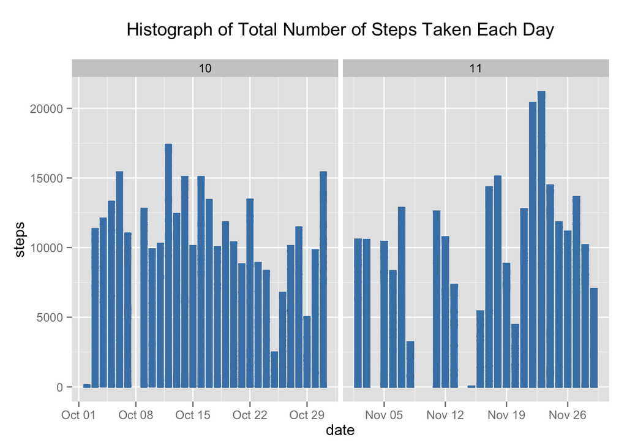

```r
data_noNA$month  <- as.numeric(format(data_noNA$date,"%m"))
library(ggplot2)
histGraph <- ggplot(data_noNA, aes(date, steps))
histGraph <- histGraph + geom_bar(stat = "identity", color="steel blue", fill="steel blue", width = 0.7)
histGraph <- histGraph + facet_grid(.~month, scales = "free")
histGraph <- histGraph + labs(title="Histograph of Total Number of Steps Taken Each Day\n")
print(histGraph)
```

**2. Calculate and report the mean and median total number of steps taken per day** The mean of total number of steps taken per day is:

```r
mean(aggregate(data_noNA$steps, list(Date = data_noNA$date), FUN = "sum")$x)
```

```
## [1] 10766.19
```

The median of total number of steps taken per day is:

```r
median(aggregate(data_noNA$steps, list(Date = data_noNA$date), FUN = "sum")$x)
```

```
## [1] 10765
```

### What is the average daily activity pattern?

**1. Make a time series plot (i.e. type = “l”) of the 5-minute interval (x-axis) and the average number of steps taken, averaged across all days (y-axis)**

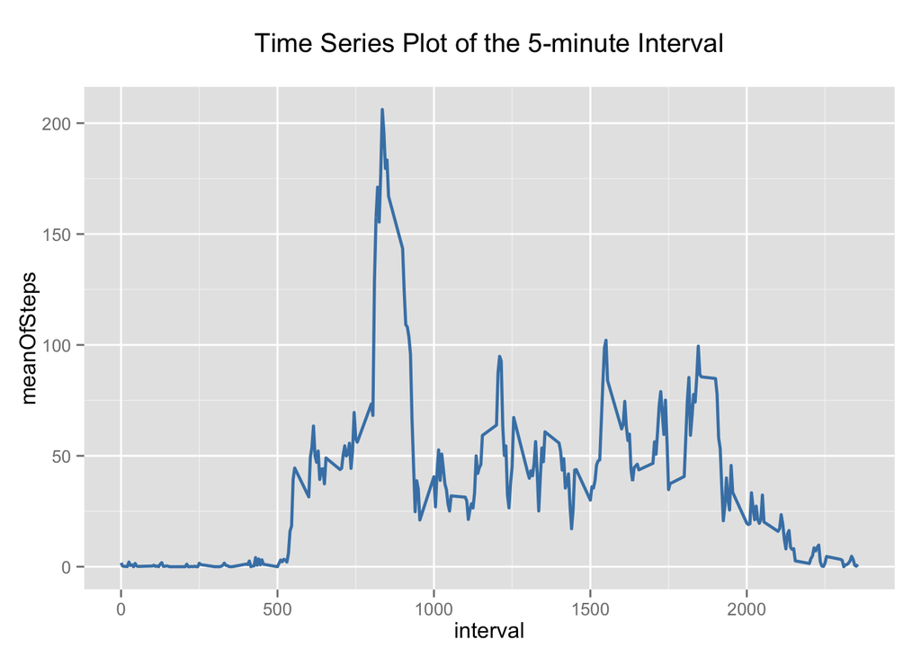

```r
avgSteps <- aggregate(data_noNA$steps, list(interval = as.numeric(as.character(data_noNA$interval))), FUN = "mean")
names(avgSteps)[2] <- "meanOfSteps"

plotGraph <- ggplot(avgSteps, aes(interval, meanOfSteps))
plotGraph <- plotGraph + geom_line(color = "steel blue", size = 0.8)
plotGraph <- plotGraph + labs(title = "Time Series Plot of the 5-minute Interval\n")
print(plotGraph)
```

**2. Which 5-minute interval, on average across all the days in the dataset, contains the maximum number of steps?**

```r
avgSteps[avgSteps$meanOfSteps == max(avgSteps$meanOfSteps), ]
```

```
##     interval meanOfSteps
## 104      835    206.1698
```